## Assignment 10

#### Due Friday, November 17, 11:59 PM CT

### Preliminaries

- Directories
  - COURSE/homework/
  - COURSE/homework/hw10/
  - COURSE/data/
  - COURSE/scripts/
- Files
  - COURSE/homework/hw10/hw10.Rmd
  - COURSE/data/boston-marathon-data.csv
  - COURSE/data/madison-weather-official-1869-2022.csv
  - COURSE/scripts/viridis.R
  - COURSE/scripts/ggprob.R

### Data

- Some problems use the official Madison weather data, `madison-weather-official-1869-2022.csv`.
- Additional problems use the Boston Marathon data in the file `boston-marathon-data.csv`. This file is a transformed version of the raw data we used in class and has data for all runners who completed the race in 2010 and 2011. The variable `Time` is the sum of the times from the different portions of the race, each of which begins with “K”.

### Aims

- Practice inference on means

## Problems

**1.** Read in the official Madison weather data. Treat the high temperatures on the dates from April 14 from the past twenty years (2003–2022) as a random sample from a population of potential maximum temperatures in Madison under recent climate conditions at this time of the year. Let $\mu$ and $\sigma$ represent the unknown mean and standard deviations of this population of high temperatures.

- Calculate and display the summary statistics $n$, $\bar{x}$, and $s$, the sample standard deviation.

```r
weather = read_csv('./../../data/madison-weather-official-1869-2022.csv')

max_temps = weather %>%
  filter(year(date) >= 2003, month(date) == 04, day(date) == 14) %>%
  select(tmax)

summary = max_temps %>%
  summarise(
    n = n(),
    x_bar = mean(tmax),
    sd = sd(tmax)
  )

print(summary)
```

```
## # A tibble: 1 × 3
##       n x_bar    sd
##   <int> <dbl> <dbl>
## 1    20  57.9  16.1
```

- Create a graph to display the distribution of this data. Choose which type of graph is effective for this purpose.

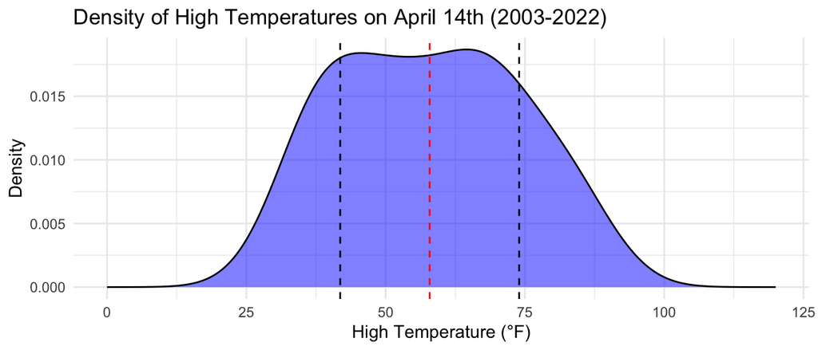

```r
ggplot(max_temps, aes(x = tmax)) +
  geom_density(fill = "blue", alpha = 0.5) +
  geom_vline(xintercept = summary$x_bar, color = "red", linetype = "dashed") +
  geom_vline(xintercept = summary$x_bar+summary$sd, color = "black", linetype = "dashed") +
  geom_vline(xintercept = summary$x_bar-summary$sd, color = "black", linetype = "dashed") +
  xlab("High Temperature (°F)") +
  xlim(0, 120) +
  ylab("Density") +
  ggtitle("Density of High Temperatures on April 14th (2003-2022)")
```

- Describe the distribution of daily maximum temperatures as shown by the graph. Is the distribution strongly skewed? Are there unusual measurements?

**2.** Compare the standard normal distribution with the t distribution with 19 degrees of freedom.

- Calculate the 0.975 quantiles from each of these two distribution.
- On the same graph, display the density functions of these two distributions, using blue for normal and red for t.
  - Add colored (use the same color scheme) dashed vertical lines at the corresponding 0.975 quantiles.
  - Shade the area in tail areas below the 0.025 and above the 0.975 quantiles of each distribution, setting `alpha = 0.5` for partial transparency.

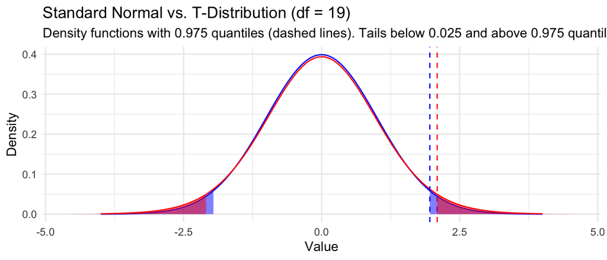

```r
q_normal = qnorm(0.975)
q_t = qt(0.975, df = 19)

q_normal_left = qnorm(0.025)
q_t_left = qt(0.025, df = 19)

x_values = seq(-4, 4, length.out = 100)

# Create a data frame for ggplot
plot_data = data.frame(
  x = x_values,
  dnorm = dnorm(x_values),
  dt = dt(x_values, df = 19)
)

ggplot(plot_data, aes(x)) +
  geom_line(aes(y = dnorm), color = "blue") +
  geom_line(aes(y = dt), color = "red") +
  geom_vline(xintercept = q_normal, color = "blue", linetype = "dashed") +
  geom_vline(xintercept = q_t, color = "red", linetype = "dashed") +
  geom_norm_fill(mu = 0, sigma = 1, a = q_normal, b = NULL, fill = "blue", alpha = 0.5) +
  geom_t_fill(df = 19, a = q_t, b = NULL, fill = "red", alpha = 0.5) +
  geom_norm_fill(mu = 0, sigma = 1, a = NULL, b = q_normal_left, fill = "blue", alpha = 0.5) +
  geom_t_fill(df = 19, a = NULL, b = q_t_left, fill = "red", alpha = 0.5) +
  xlab("Value") + ylab("Density") +
  ggtitle("Standard Normal vs. T-Distribution (df = 19)") +
  labs(subtitle = "Density functions with 0.975 quantiles (dashed lines). Tails below 0.025 and above 0.975 quantiles shaded")
```

**3.** Using the data from Problem 1:

- Construct a 95% confidence interval for $\mu$ using the theory of the t distribution by direct calculation using the summary statistics from the first part of the problem.

```r
temps_sd = (summary$sd)/sqrt(summary$n)

z = qt(0.975, df=19)
ci = (summary$x_bar) + c(-1,1)*z*temps_sd
round(ci,3)
```

```
## [1] 50.384 65.416
```

- Then use the `t.test()` function to verify your calculation.

```r
(t.test(max_temps))$conf.int
```

```
## [1] 50.38426 65.41574
## attr(,"conf.level")
## [1] 0.95
```

- Interpret the interval in context.

> We are 95% confident that the mean max temperature on April 14 for the past twenty years would have been between 50.384 and 65.416 degrees.

**4.** The historical average daily high temperature in Madison in April prior to 2000 is 55.6 degrees Farhenheit. Let $\mu$ be the expected daily high temperature on April 14 in the past two recent decades.

- Use a hypothesis test to test if $\mu$ equals 55.6 degrees versus the alternative that it is different. Include all steps as in the lecture notes.

> Test the hypothesis that the mean daily high temperature $\mu = 55.6$ minutes versus the alternative that it is not ($\mu \neq 55.6$ minutes).

### Population and Sample

- The population are daily high temperatures in April prior to 2000.
- The sample is the daily high temperature on April 14 in the past two recent decades, 20 observations.

### Statistical Model

- Individuals temperatures are $x_1, \ldots, x_n$ for $n = 20$.
- Model these times as a random sample from the larger population
  - Let $F$ be this unspecified distribution
  - Let $\mu$ be the mean
  - Let $\sigma$ be the standard deviation

$$X_i \sim F(\mu, \sigma), \quad i = 1, \ldots, n$$

### State Hypotheses

$H_0: \mu = 55.6$  
$H_a: \mu \neq 55.6$

### Choose a Test Statistic

- We will standardize the sample mean by subtracting the (assumed) population mean and dividing by an estimated standard error.
- Compare this normalized statistic to a distribution known from mathematical statistics

$$T = \frac{\bar{X} - \mu_0}{s / \sqrt{n}}$$
where:

- sample mean: $\bar{X} = \displaystyle \frac{\sum_{i=1}^n X_i}{n}$
  - R function `mean()`
- sample standard deviation $s = \displaystyle \sqrt{ \sum_{i=1}^n \frac{(x_i - \bar{x})^2}{n-1}}$
  - R function `sd()`
- $\mu_0$ is the numerical value assumed equal to $\mu$ under $H_0$.
- Here is the calculation for the observed test statistic (assuming the null hypothesis is true)

```r
## Assuming the null
mu0 = 55.6

summary = summary %>%
  mutate(tstat = (x_bar - mu0)/(sd/sqrt(n)))

tstat = summary %>%
  pull(tstat)

summary
```

```
## # A tibble: 1 × 4
##       n x_bar    sd tstat
##   <int> <dbl> <dbl> <dbl>
## 1    20  57.9  16.1 0.641
```

```r
tstat
```

```
## [1] 0.6405167
```

- We may interpret the test statistic in this way:

> The observed sample mean is approximately 0.641 standard errors away (above or below) from the null hypothesis mean of 55.6 degrees Fahrenheit. This indicates how extreme the sample mean is in comparison to what we would expect if the true mean were indeed 55.6 degrees Fahrenheit.
- The p-value is the area to the left (Left because $H_a: \mu < 55.6$) and right (Right because $H_a: \mu > 55.6$) of the test statistic under the null sampling distribution.
- The function `pt(x, df)` calculates the probability (area) to the left of `x` under a `t` density with `df` degrees of freedom (more on this term later).
- The observed test statistic is $T_{obs} = 0.64$
- Statistics which are at least as favorable to the alternative hypothesis are those values less than or equal to $T_{obs}$.

```r
# Calculate the p-value for a two-tailed test
pvalue = 2 * pt(-abs(tstat), df = summary$n - 1)

# Display the p-value
pvalue
```

```
## [1] 0.5294866
```

- Conclude your hypothesis test with an interpretation in context which states your conclusion in plain language without technical jargon and summarizes the statistical evidence to support your conclusion in a statement surrounded by parentheses.

> The p-value from our hypothesis test is 0.5294866. This value is greater than the common significance level of 0.05, which means there is not enough statistical evidence to reject the null hypothesis. Therefore, based on this analysis, we conclude that there is no significant difference between the mean daily high temperature on April 14 for the past two decades and the historical average of 55.6 degrees Fahrenheit.

> Check using t.test()

```r
t.test(max_temps, mu=55.6)
```

```
##
##  One Sample t-test
##
## data:  max_temps
## t = 0.64052, df = 19, p-value = 0.5295
## alternative hypothesis: true mean is not equal to 55.6
## 95 percent confidence interval:
##  50.38426 65.41574
## sample estimates:
## mean of x
##      57.9
```

**5.** This problem asks you to compare the latest date in each winter when there was at least one inch of snow for two different time periods using the official Madison weather data. and the years 1903–1922:

- Create a data set with the latest date from January to June in each year where there was at least one inch of snow for the years 1903–1922 and 2003–2022.
- Use the **lubridate** function `yday()` to create a new variable `yday` by converting this date into the number of days after December 31.
- Add a variable named `period` which has the value `"early 1900s"` for years 1903–1922 and `"early 2000s"` for the years 2003–2022.

```r
filtered_weather = weather %>%
  filter((year(date) >= 1903 & year(date) <= 1922 | year(date) >= 2003 & year(date) <= 2022) &
         snow >= 1 &
         month(date) >= 1 & month(date) <= 6) %>%
  group_by(year = year(date)) %>%
  filter(date == max(date)) %>%
  mutate(yday = yday(date)) %>%
  mutate(period = ifelse(year(date) >= 1903 & year(date) <= 1922, "early 1900s", "early 2000s"))

print(filtered_weather, n=10)
```

```
## # A tibble: 40 × 11
## # Groups:   year [40]
##    name   date        prcp  snow snow_depth  tmin  tmax  tavg  year  yday period
##    <chr>  <date>     <dbl> <dbl>      <dbl> <dbl> <dbl> <dbl> <dbl> <dbl> <chr>
##  1 Bureau 1903-04-21  0.07   1           NA    31    47  39    1903   111 early…
##  2 Bureau 1904-03-14  0.19   6           NA    20    25  22.5  1904    74 early…
##  3 Bureau 1905-04-21  0.22   1            0    31    52  41.5  1905   111 early…
##  4 Bureau 1906-04-05  0.24   1.2          0    31    44  37.5  1906    95 early…
##  5 Bureau 1907-04-07  1.19   4            3    32    36  34    1907    97 early…
##  6 Bureau 1908-02-19  0.24   4.2          6    14    23  18.5  1908    50 early…
##  7 Bureau 1909-03-09  0.43   3.8          3    28    31  29.5  1909    68 early…
##  8 Bureau 1910-04-23  0.8    7.3          7    19    30  24.5  1910   113 early…
##  9 Bureau 1911-04-06  0.44   3.6          4    24    34  29    1911    96 early…
## 10 Bureau 1912-04-18  0.14   1.4          0    28    48  38    1912   109 early…
## # ℹ 30 more rows
```

- Calculate the sample size, the sample mean, and the sample standard deviation for each period.

```r
sample_details = filtered_weather %>%
  group_by(period) %>%
  summarise(n = n(),
            mean = mean(yday),
            sd = sd(yday))

sample_details
```

```
## # A tibble: 2 × 4
##   period          n  mean    sd
##   <chr>       <int> <dbl> <dbl>
## 1 early 1900s    20  84.0  19.8
## 2 early 2000s    20  90.9  16.8
```

- Create a graph to compare these two distributions.

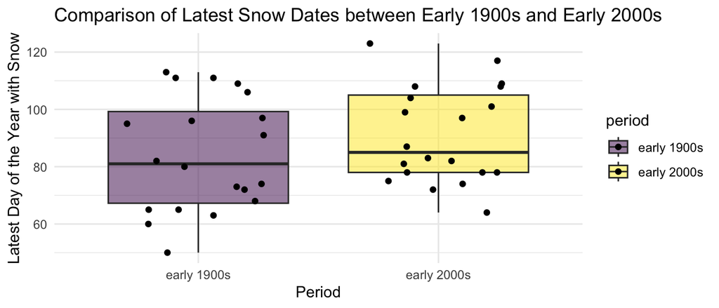

```r
ggplot(filtered_weather, aes(x = period, y = yday, fill = period)) +
  geom_boxplot(coef = Inf, alpha = 0.5) +
  geom_point(position = position_jitter(width=0.3, height=0)) +
  labs(title = "Comparison of Latest Snow Dates between Early 1900s and Early 2000s",
       x = "Period",
       y = "Latest Day of the Year with Snow") +
  theme_minimal()
```

> The boxplot comparison of the latest significant snowfall dates between the early 1900s and early 2000s shows that the early 2000s generally experienced later snowfalls in the year. This is indicated by the higher median and interquartile range in the early 2000s boxplot. The positioning of these boxplots suggests that both the typical and the range of the latest snow dates in the early 2000s occurred later in the year compared to the early 1900s.

**6.** Using the data from the previous problem:

- Use `t.test()` to construct a confidence interval for the difference in the mean last day of at least one inch of snow between these two time periods.
  - Interpret the confidence interval in context.

```r
s1_data = filtered_weather %>% filter(period == 'early 1900s') %>% pull(yday)
s2_data = filtered_weather %>% filter(period == 'early 2000s') %>% pull(yday)

(t.test(s1_data, s2_data))$conf.int
```

```
## [1] -18.609478   4.909478
## attr(,"conf.level")
## [1] 0.95
```

```r
t.test(s1_data, s2_data)
```

```
##
##  Welch Two Sample t-test
##
## data:  s1_data and s2_data
## t = -1.1802, df = 37.047, p-value = 0.2454
## alternative hypothesis: true difference in means is not equal to 0
## 95 percent confidence interval:
##  -18.609478   4.909478
## sample estimates:
## mean of x mean of y
##     84.05     90.90
```

> The p-value of 0.2454 from our t-test indicates that there is no statistically significant difference at the 5% significance level in the mean last day of at least one inch of snow between the ‘early 1900s’ and ‘early 2000s’ periods. This means that, based on our sample data, we do not have enough evidence to reject the null hypothesis that the population means are identical in the two periods.

**7.** Using the Boston Marathon data, treat the finishing times of men aged 35–39 in 2010 as a sample from a larger population of men worldwide who could have completed the Boston marathon that year.

- Calculate a numerical summary of the times to finish the race from this sample, including the sample size, sample mean, sample standard deviation, and the 0.10, 0.25, 0.50, 0.75, and 0.90 quantiles.

```r
bm = read_csv('./../../data/boston-marathon-data.csv')

bm_summary = bm %>%
  filter(Age_Range == '35-39' & Sex == 'male' & Year == '2010') %>%
  summarise(
    n = n(),
    mean = mean(Time, na.rm = TRUE),
    sd = sd(Time, na.rm = TRUE),
    quantile10 = quantile(Time, 0.10, na.rm = TRUE),
    quantile25 = quantile(Time, 0.25, na.rm = TRUE),
    median = quantile(Time, 0.50, na.rm = TRUE),
    quantile75 = quantile(Time, 0.75, na.rm = TRUE),
    quantile90 = quantile(Time, 0.90, na.rm = TRUE)
  )

bm_summary
```

```
## # A tibble: 1 × 8
##       n  mean    sd quantile10 quantile25 median quantile75 quantile90
##   <int> <dbl> <dbl>      <dbl>      <dbl>  <dbl>      <dbl>      <dbl>
## 1  1769  214.  38.5       177.       189.   202.       230.       272.
```

- Choose a type of graph and display the distribution of the sample finish times.

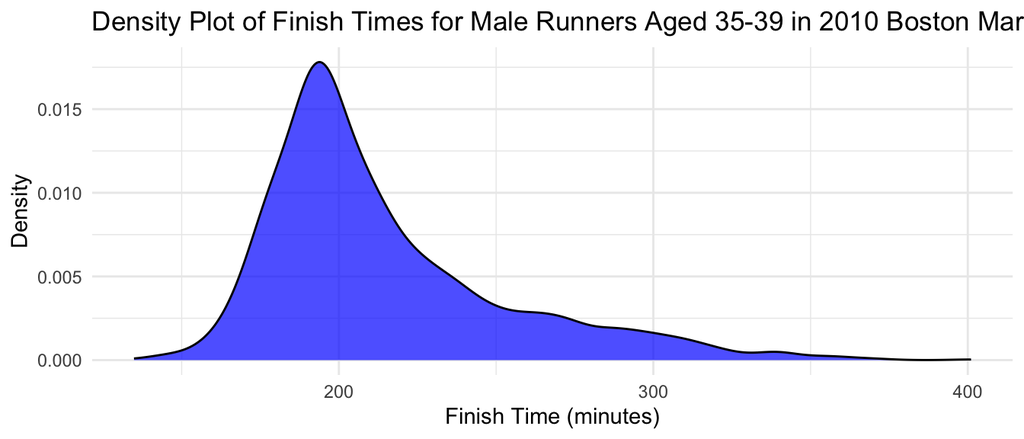

```r
bm_filtered = bm %>%
  filter(Age_Range == '35-39' & Sex == 'male' & Year == 2010)

ggplot(bm_filtered, aes(x = Time)) +
  geom_density(fill = "blue", alpha = 0.7) +
  labs(title = "Density Plot of Finish Times for Male Runners Aged 35-39 in 2010 Boston Marathon",
       x = "Finish Time (minutes)",
       y = "Density") +
  theme_minimal()
```

- Find a 95% confidence interval for the mean finishing time in the population using methods of the t distribution by direct calculation

```r
ci_calc = bm_summary %>%
  mutate(se = sd/sqrt(n),
         tmult = qt(0.975, n-1),
         me = tmult*se,
         low = mean - me,
         high = mean + me)
ci_calc %>%
  print(width = Inf)
```

```
## # A tibble: 1 × 13
##       n  mean    sd quantile10 quantile25 median quantile75 quantile90    se
##   <int> <dbl> <dbl>      <dbl>      <dbl>  <dbl>      <dbl>      <dbl> <dbl>
## 1  1769  214.  38.5       177.       189.   202.       230.       272. 0.915
##   tmult    me   low  high
##   <dbl> <dbl> <dbl> <dbl>
## 1  1.96  1.80  212.  216.
```

```r
ci = ci_calc %>%
  select(low, high)

ci
```

```
## # A tibble: 1 × 2
##     low  high
##   <dbl> <dbl>
## 1  212.  216.
```

- Repeat the calculations using the `t.test()` function

```r
(t.test(bm_filtered$Time))$conf.int
```

```
## [1] 212.2629 215.8531
## attr(,"conf.level")
## [1] 0.95
```

- Interpret this confidence interval in context following the format of examples from lecture.

> > We are 95% confident that the mean finishing time of men aged 35-39 capable of finishing the Boston Marathon in 2010 would have been between 212.2629 and 215.8531 minutes.

**8.** Treat the finishing times in the Boston Marathon of men aged 35–39 in 2010 and 2011 as two different independent samples. Is there evidence that the mean time to finish the race among a population of potential finishers changed during these two years? Conduct a hypothesis test to support your conclusion.

### Explore

- Here, we have two independent samples
- Will make side-by-side box plots and overlay the actual points
  - We set `coef=Inf` so that single points are not labeled as outliers
  - As we plot all points individually, it is distracting and misleading to plot the outliers twice

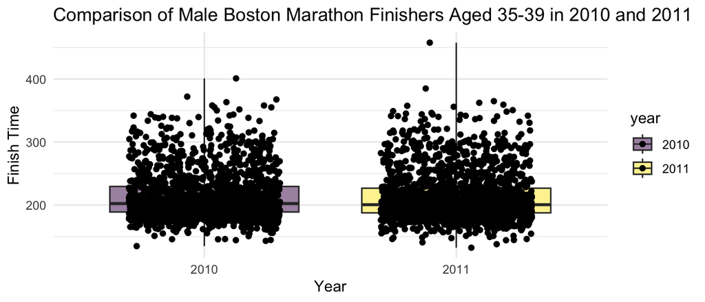

```r
bm_both = bm %>%
  filter(Age_Range == '35-39' & Sex == 'male' & (Year == 2010 | Year == 2011)) %>%
  mutate(year = as.character(Year))

ggplot(bm_both, aes(x = year, y = Time, fill = year)) +
  geom_boxplot(coef = Inf, alpha = 0.5) +
  geom_point(position = position_jitter(width=0.3, height=0)) +
  xlab("Year") +
  ylab("Finish Time") +
  ggtitle("Comparison of Male Boston Marathon Finishers Aged 35-39 in 2010 and 2011") +
  theme_minimal()
```

### Population and Sample

- The population are Boston Marathon Finishers in 2010 and 2011.
- The sample are the Boston Marathon men finishers aged 35-39 in 2010 and 2011 respectively.

### Model

- We have two independent samples
- Treat the data as randomly sampled from larger populations.

$X_i \sim F_1(\mu_1, \sigma_1), \quad i = 1, \ldots, n_1$  
$Y_i \sim F_2(\mu_2, \sigma_2), \quad i = 1, \ldots, n_2$

```r
bm_summary = bm_both %>%
  group_by(year) %>%
  summarise(
    n = n(),
    mean = mean(Time),
    sd = sd(Time)
  )

bm_summary
```

```
## # A tibble: 2 × 4
##   year      n  mean    sd
##   <chr> <int> <dbl> <dbl>
## 1 2010   1769  214.  38.5
## 2 2011   1845  212.  38.9
```

> Find a 95% Confidence Interval for $\mu_1 - \mu_2$

```r
# Subset data for the two years
data_2010 = bm %>% filter(Age_Range == '35-39', Sex == 'male', Year == 2010) %>% pull(Time)
data_2011 = bm %>% filter(Age_Range == '35-39', Sex == 'male', Year == 2011) %>% pull(Time)

# Conduct two-sample t-test
t_test_result = t.test(data_2010, data_2011)

t_test_result
```

```
##
##  Welch Two Sample t-test
##
## data:  data_2010 and data_2011
## t = 1.2249, df = 3608.6, p-value = 0.2207
## alternative hypothesis: true difference in means is not equal to 0
## 95 percent confidence interval:
##  -0.9477035  4.1031083
## sample estimates:
## mean of x mean of y
##  214.0580  212.4803
```

```r
dof = 3608.6 #t.test(x, y)$parameter
mean_x=mean(data_2010)
s_x = sd(data_2010)
n_x = length(data_2010)

mean_y = mean(data_2011)
s_y = sd(data_2011)
n_y = length(data_2011)

ci = mean_x - mean_y + c(-1,1)*qt(0.975, dof)*sqrt(s_x^2/n_x + s_y^2/n_y)
ci
```

```
## [1] -0.9477035  4.1031083
```